# Decision_treeTASK5

## TSF DATA SCIENCE TASK 6

### PREDICTION USING DECISION TREE ALGORITHM

### Data Science and Business Analytics intern at The Sparks Foundation.

## Flow of Analysis

1. Introduction
2. Import the required libraries
3. Exploratory Data Analysis
4. Building a prediction model

### 1. INTRODUCTION

Using sklearn datasets [Iris data set](https://bit.ly/3i4rbWl) to train our model using Decision tree classifier. We will figure out accuracy of your model and use that to predict different samples in our test dataset. The data contain the following features:

1. Sepal Length
2. Sepal Width
3. Petal Length
4. Petal Width

Using above 4 features you will clasify a flower in one of the three categories,

1. Setosa
2. Versicolour
3. Virginica

## 2. IMPORT LIBRARIES

```python
#import libraries for the workflow
import numpy as np
import matplotlib.pyplot as plt
import pandas as pd
from sklearn import datasets

##LIBRARY FOR VISUALIZATION
from autoviz.AutoViz_Class import AutoViz_Class
AV = AutoViz_Class()
import seaborn as sns
%matplotlib inline

## lIBRARY FOR MODELLING
from sklearn.preprocessing import LabelEncoder
from sklearn.model_selection import train_test_split
from sklearn import tree
import graphviz
from sklearn.tree import DecisionTreeClassifier
from sklearn.model_selection import train_test_split, cross_val_score
from sklearn.metrics import multilabel_confusion_matrix, accuracy_score
from sklearn.metrics import multilabel_confusion_matrix, accuracy_score
```

### 3. Exploratory Data Analysis

We will employ the [Autoviz](https://pypi.org/project/autoviz/) for a total visualization of the dataset.

```
Shape of your Data Set loaded: (150, 6)
#######################################################################################
######################## C L A S S I F Y I N G  V A R I A B L E S  ####################
#######################################################################################
Classifying variables in data set...
    Number of Numeric Columns =  4
    Number of Integer-Categorical Columns =  0
    Number of String-Categorical Columns =  0
    Number of Factor-Categorical Columns =  0
    Number of String-Boolean Columns =  0
    Number of Numeric-Boolean Columns =  0
    Number of Discrete String Columns =  0
    Number of NLP String Columns =  0
    Number of Date Time Columns =  0
    Number of ID Columns =  1
    Number of Columns to Delete =  0
    5 Predictors classified...
        1 variables removed since they were ID or low-information variables

################ Multi_Classification problem #####################
```

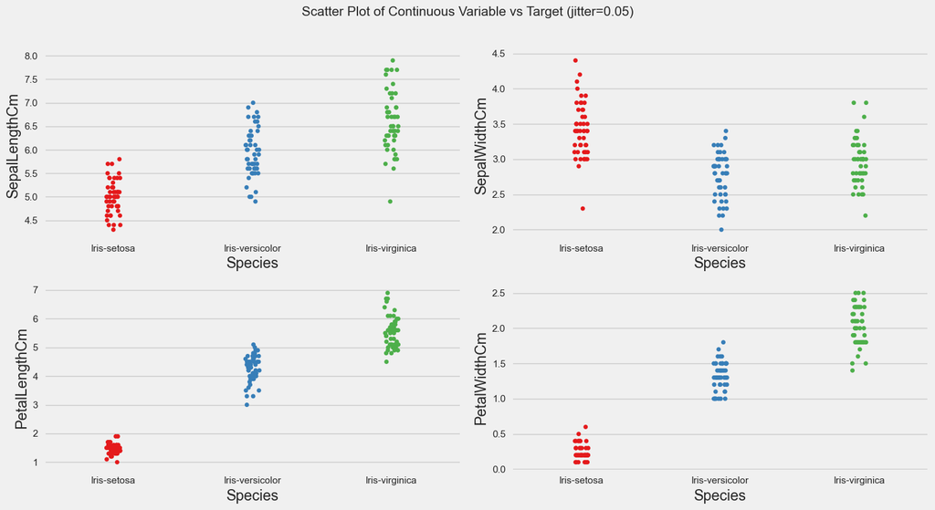

```
Total Number of Scatter Plots = 10
```

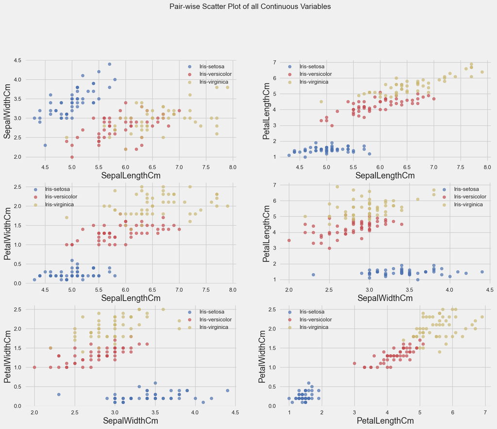

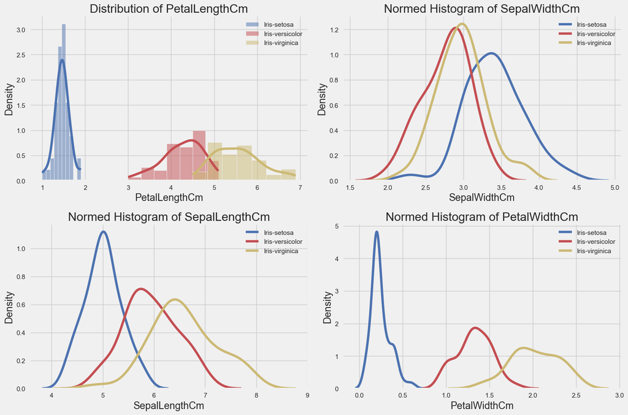

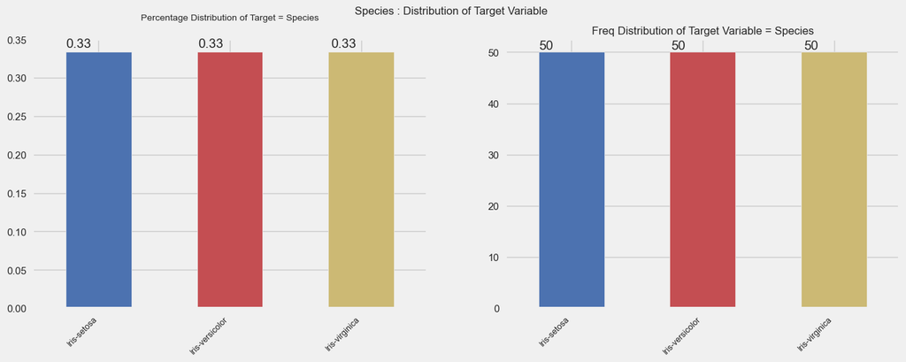

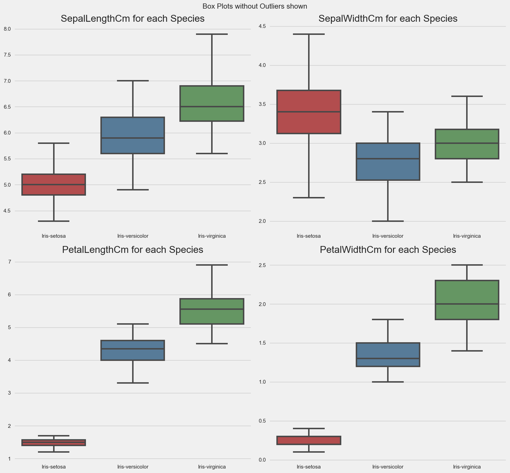

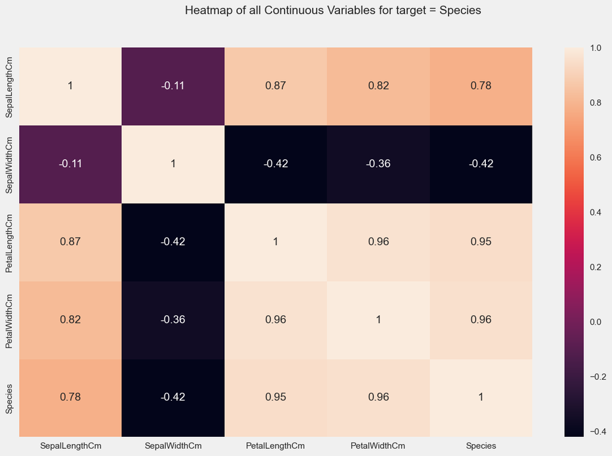

```
No categorical or boolean vars in data set. Hence no pivot plots...
No categorical or numeric vars in data set. Hence no bar charts.
All Plots done
Time to run AutoViz = 10 seconds

 ###################### AUTO VISUALIZATION Completed ########################
```

```python
filename = 'iriss.csv'
sep = ","
dft = AV.AutoViz(
filename,
sep=",",
depVar="Species",
dfte=None,
header=0,
verbose=0,
lowess=False,
chart_format="svg",
max_rows_analyzed=150000,
max_cols_analyzed=50,
)
```

**A corresponding correlation matrix to quantitatively examine the relationship between variables is also produced. The following are the takebacks form the correlation matrix:**

1. Petal measurements have highly positive correlation  
2. Sepal measurements are uncorrelated.  
3. Petal features also have relatively high correlation with sepal_length, but not with sepal_width.

## 4. DATA MODELLING AND ANALYSIS

We have gained some insight into the data, so we are looking at modelling the data using suitable machine learning algorithm specifically Decision tree.

```python
data = pd.read_csv('iriss.csv')
```

##### Train-Test Split

Now, we can split the dataset into a training set and a test set. The test set will be use for the purpose of reporting and validation of our model. In addition, I used either a stratified hold-out approach or cross validation to estimate model accuracy if the need arise.

Generally, the rule of thumb is have 20–30% of dataset as the test set but due to the size of our dataset, we will take 30% to ensure there are enough data points to test the model performance.

```python
data.columns
```

```
Index(['Id', 'SepalLengthCm', 'SepalWidthCm', 'PetalLengthCm', 'PetalWidthCm',
       'Species'],
      dtype='object')
```

```python
X = data[['SepalLengthCm', 'SepalWidthCm', 'PetalLengthCm', 'PetalWidthCm']]
y = data['Species']
```

```python
#Rename "class" column to avoid conflict with inbuilt function
#data.rename(columns = {'sepal_length':'sepal_length', 'sepal_width':'sepal_width', 'petal_length':'petal_length', 'petal_width':'petal_width', 'Species':'target'}, inplace = True)
```

```python
#Check the distribution of the data set by class
#data.groupby('target').size()
```

```python
Xtrain, Xtest, Ytrain, Ytest = train_test_split(X, y, test_size=0.30, random_state=2)
```

```python
#spliting training data into validation train and validation test
Xt, Xcv, Yt, Ycv = train_test_split(Xtrain, Ytrain, test_size=0.10, random_state=3)
```

```python
'''Now we have create a Decision tree classifier and trained it with training dataset.'''
data_clf = DecisionTreeClassifier(criterion='gini',min_samples_split=2)
data_clf.fit(Xt, Yt)
```

```
DecisionTreeClassifier()
```

```
[Text(0.36363636363636365, 0.9285714285714286, 'X[2] <= 2.35\ngini = 0.663\nsamples = 94\nvalue = [27, 32, 35]'),
```

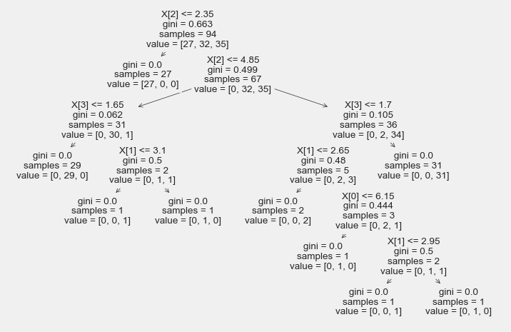

```python
'''Visualized the Tree which is formed on train dataset'''

tree.plot_tree(data_clf)
```

```python
'''Visualizing Decision Tree using graphviz library'''

grpdata = tree.export_graphviz(data_clf, out_file=None)

graph = graphviz.Source(grpdata)
graph
```

[figure not shown]

```python
''' As our model has been trained we can validate our Decision tree using cross validation method to get the accuracy or performance score of our model.'''

print('Accuracy score is:',cross_val_score(data_clf, Xt, Yt, cv=3, scoring='accuracy').mean())
```

```
Accuracy score is: 0.9361559139784946
```

```python
'''Checking validation test data on our trained model and getting performance metrices.'''

Y_hat = data_clf.predict(Xcv)
print('Accuracy score for validation test data is:',accuracy_score(Ycv, Y_hat))
multilabel_confusion_matrix(Ycv , Y_hat)
```

```
Accuracy score for validation test data is: 0.9090909090909091
```

```
array([[[5, 0],
        [0, 6]],

       [[8, 0],
        [1, 2]],

       [[8, 1],
        [0, 2]]], dtype=int64)
```

```python
'''Checking our model performance on actual unseen test data'''
YT_hat = data_clf.predict(Xtest)
YT_hat

print('Model Accuracy Score on totally unseen data(Xtest) is:',accuracy_score(Ytest, YT_hat)*100,'%')
multilabel_confusion_matrix(Ytest , YT_hat)
```

```
Model Accuracy Score on totally unseen data(Xtest) is: 95.55555555555556 %
```

```
array([[[28,  0],
        [ 0, 17]],

       [[29,  1],
        [ 1, 14]],

       [[31,  1],
        [ 1, 12]]], dtype=int64)
```

*As we know our selected feature are working well and model gives very good accuracy score on validate or actual test data. So Now we can trained our model on Actual train dataset with selected features for evaluating/ deploying our model in real world cases.*

```
[Text(0.4, 0.9, 'X[2] <= 2.35\ngini = 0.666\nsamples = 105\nvalue = [33, 35, 37]'),
```

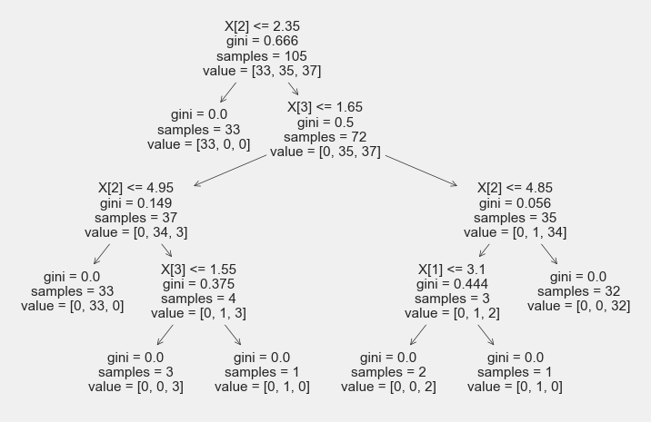

```python
'''Training model on Actual train data... '''
dataFclf = DecisionTreeClassifier(criterion='gini',min_samples_split=2)
dataFclf.fit(Xtrain, Ytrain)

#Visualize tree structure..
tree.plot_tree(dataFclf)
```

```python
'''Visualizing Decision Tree using graphviz library'''

grpfdata = tree.export_graphviz(dataFclf, out_file=None)

graph1 = graphviz.Source(grpfdata)
graph1
```

[figure not shown]

```python
'''Checking the performance of model on Actual Test data'''

YT_Fhat = dataFclf.predict(Xtest)
YT_Fhat

print('Model Accuracy Score on totally unseen data(Xtest) is:',accuracy_score(Ytest, YT_Fhat)*100,'%')
multilabel_confusion_matrix(Ytest , YT_Fhat)
```

```
Model Accuracy Score on totally unseen data(Xtest) is: 95.55555555555556 %
```

```
array([[[28,  0],
        [ 0, 17]],

       [[29,  1],
        [ 1, 14]],

       [[31,  1],
        [ 1, 12]]], dtype=int64)
```

### Conclusion

The test model score was about 95% accuracy, which is also a very good one. Showing that our tain model is actually not overfiting the model.

We explored the Iris dataset, and then built a decision tree or real world deployment. We saw that the petal measurements are more helpful at classifying instances of flowers than the sepal ones. Furthermore, ourmodels achieved a test accuracy of 95%.